# Effects of User Type, Time and Day on the Average Ride Duration

## by Emmanuel Boluwaji Adeyeye

## Investigation Overview

In this investigation, I wanted to look at the features that have the most effect on the average ride duration. The main focus was on the user type, start hour, and day of the week the rides were made.

## Dataset Overview

This dataset contains information about 183,412 rides made in February 2022 in a bike-sharing system covering the greater San Francisco Bay area. The attributes include the start and end times of the rides, the year of birth of the user, and the user type. 8780 data points were removed from the analysis due to inconsistencies or missing information.

## Distribution of Ride Durations

Ride durations in the dataset take on a large range of values, from about 1 at the lowest, to about 450 at the highest. Plotted on a logarithmic scale, the distribution of ride durations takes on a unimodal shape.

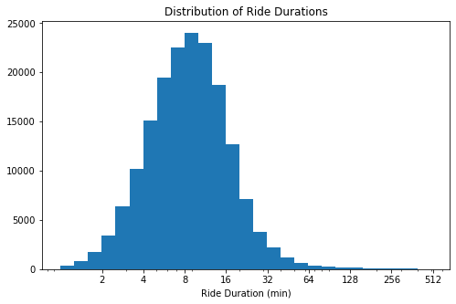

## Percentage of user type

The user type has two values: Subscriber and customer. The subscribers pay a fixed amount monthly whereas the customers are charged a fixed amount for one-way trips per day. 90.5% of the rides were made by subscribers while customers made 9.5% of the rides.

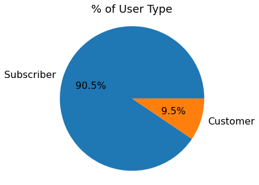

## Average Ride Duration by User Type

The mean of the ride duration by customers is almost 100% higher than that of subscribers as depicted on the violin plots. This accounts for the base observation that the average duration of a ride made by a customer is longer than that of a subscriber.

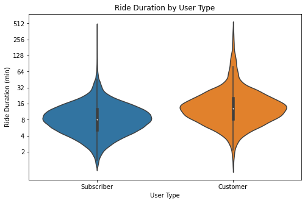

## Average Ride Duration over Time

The average ride duration is highest at around 3 and lowest around 6 daily. It is also highest on weekends.

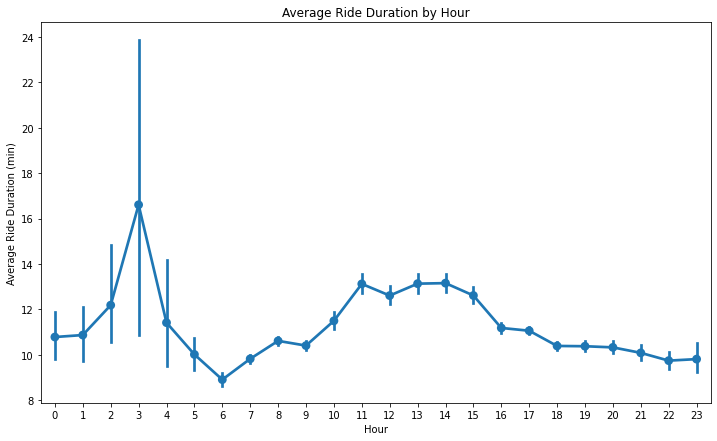

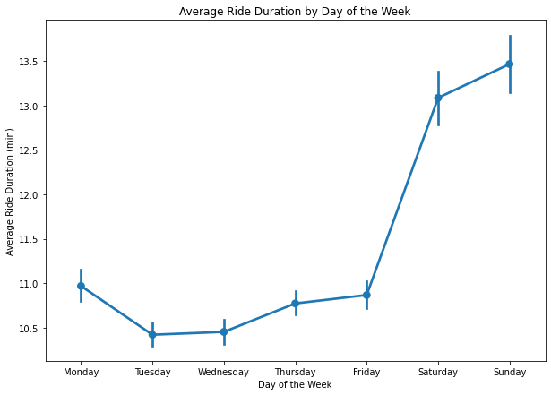

## User Type Over Time

The number of rides by subscribers around 8 and 17 looks almost the same. This shows that most of the people that made the rides around 8 were the ones that used the bike share service around 17. More rides were made by customers around 17 than every other hour. Subscribers majorly make more rides on weekdays whereas the number of customers' rides on weekends is not significantly different from that made on weekdays.

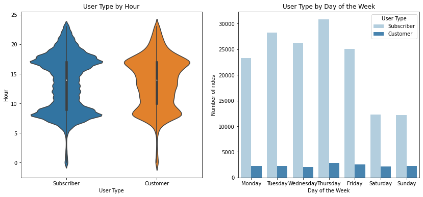

## Average Ride Duration over Time for the User Types

The average ride duration for both subscribers and customers is highest at 3. The spike in the average duration for customers on weekends is remarkable compared to that of subscribers.

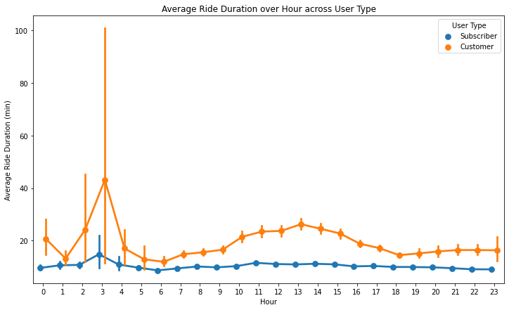

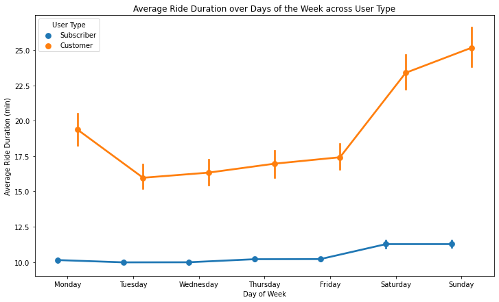